# Modelos sobre Casen-Censo

Regresión lineal

VE-CC-AJ

DataIntelligence

Lunes 21-06-2021

Abstract

En un [trabajo anterior](https://rpubs.com/dataintelligence/expansion_viviendas_001), obtuvimos una tabla la que tiene dos campos sobre los cuales queremos aplicar un modelo de regresión lineal: multi_pob y p_variable. En éste Rpubs excluiremos NAs, outliers, aplicaremos el análisis de regresión y ensayaremos distintas fórmulas de modelos para poder elegir el apropiado.

## 0 Lectura de la tabla madre

```r
tabla_001 <- readRDS("tabla_001.rds")
r3_100 <- tabla_001[c(1:100),]
kbl(r3_100) %>%
  kable_styling(bootstrap_options = c("striped", "hover")) %>%
  kable_paper() %>%
  scroll_box(width = "100%", height = "300px")
```

| zona | código.x | Freq.x | anio | p | comuna.x | promedio_i | año | comuna.y | personas | Ingresos_expandidos | Freq.y | p_poblacional | código.y | multi_pob | p_variable |
| --- | --- | --- | --- | --- | --- | --- | --- | --- | --- | --- | --- | --- | --- | --- | --- |
| 10101011001 | 10101 | 60 | 2017 | 0.0055366 | Puerto Montt | 268732.4 | 2017 | 10101 | 245902 | 66081845388 | 584 | 0.0023749 | 10101 | 156939747 | 0.0002440 |
| 10101011002 | 10101 | 177 | 2017 | 0.0163329 | Puerto Montt | 268732.4 | 2017 | 10101 | 245902 | 66081845388 | 2941 | 0.0119600 | 10101 | 790342117 | 0.0007198 |
| 10101021001 | 10101 | 82 | 2017 | 0.0075667 | Puerto Montt | 268732.4 | 2017 | 10101 | 245902 | 66081845388 | 3953 | 0.0160755 | 10101 | 1062299350 | 0.0003335 |
| 10101021002 | 10101 | 77 | 2017 | 0.0071053 | Puerto Montt | 268732.4 | 2017 | 10101 | 245902 | 66081845388 | 1107 | 0.0045018 | 10101 | 297486815 | 0.0003131 |
| 10101021003 | 10101 | 70 | 2017 | 0.0064594 | Puerto Montt | 268732.4 | 2017 | 10101 | 245902 | 66081845388 | 2294 | 0.0093289 | 10101 | 616472226 | 0.0002847 |
| 10101021004 | 10101 | 99 | 2017 | 0.0091354 | Puerto Montt | 268732.4 | 2017 | 10101 | 245902 | 66081845388 | 3391 | 0.0137900 | 10101 | 911271717 | 0.0004026 |
| 10101021005 | 10101 | 171 | 2017 | 0.0157793 | Puerto Montt | 268732.4 | 2017 | 10101 | 245902 | 66081845388 | 2564 | 0.0104269 | 10101 | 689029986 | 0.0006954 |
| 10101031001 | 10101 | 133 | 2017 | 0.0122728 | Puerto Montt | 268732.4 | 2017 | 10101 | 245902 | 66081845388 | 4530 | 0.0184220 | 10101 | 1217357970 | 0.0005409 |
| 10101031002 | 10101 | 115 | 2017 | 0.0106118 | Puerto Montt | 268732.4 | 2017 | 10101 | 245902 | 66081845388 | 4740 | 0.0192760 | 10101 | 1273791783 | 0.0004677 |
| 10101031003 | 10101 | 94 | 2017 | 0.0086740 | Puerto Montt | 268732.4 | 2017 | 10101 | 245902 | 66081845388 | 4107 | 0.0167018 | 10101 | 1103684147 | 0.0003823 |
| 10101031004 | 10101 | 88 | 2017 | 0.0081203 | Puerto Montt | 268732.4 | 2017 | 10101 | 245902 | 66081845388 | 2856 | 0.0116144 | 10101 | 767499859 | 0.0003579 |
| 10101031005 | 10101 | 146 | 2017 | 0.0134724 | Puerto Montt | 268732.4 | 2017 | 10101 | 245902 | 66081845388 | 5690 | 0.0231393 | 10101 | 1529087605 | 0.0005937 |
| 10101031006 | 10101 | 94 | 2017 | 0.0086740 | Puerto Montt | 268732.4 | 2017 | 10101 | 245902 | 66081845388 | 2460 | 0.0100040 | 10101 | 661081812 | 0.0003823 |
| 10101031007 | 10101 | 39 | 2017 | 0.0035988 | Puerto Montt | 268732.4 | 2017 | 10101 | 245902 | 66081845388 | 2292 | 0.0093208 | 10101 | 615934761 | 0.0001586 |
| 10101031008 | 10101 | 54 | 2017 | 0.0049829 | Puerto Montt | 268732.4 | 2017 | 10101 | 245902 | 66081845388 | 3585 | 0.0145790 | 10101 | 963405811 | 0.0002196 |
| 10101031009 | 10101 | 166 | 2017 | 0.0153179 | Puerto Montt | 268732.4 | 2017 | 10101 | 245902 | 66081845388 | 4436 | 0.0180397 | 10101 | 1192097121 | 0.0006751 |
| 10101031010 | 10101 | 92 | 2017 | 0.0084894 | Puerto Montt | 268732.4 | 2017 | 10101 | 245902 | 66081845388 | 3566 | 0.0145017 | 10101 | 958299894 | 0.0003741 |
| 10101031011 | 10101 | 49 | 2017 | 0.0045215 | Puerto Montt | 268732.4 | 2017 | 10101 | 245902 | 66081845388 | 2757 | 0.0112118 | 10101 | 740895347 | 0.0001993 |
| 10101031012 | 10101 | 94 | 2017 | 0.0086740 | Puerto Montt | 268732.4 | 2017 | 10101 | 245902 | 66081845388 | 1849 | 0.0075193 | 10101 | 496886289 | 0.0003823 |
| 10101031013 | 10101 | 73 | 2017 | 0.0067362 | Puerto Montt | 268732.4 | 2017 | 10101 | 245902 | 66081845388 | 3945 | 0.0160430 | 10101 | 1060149491 | 0.0002969 |
| 10101031014 | 10101 | 109 | 2017 | 0.0100581 | Puerto Montt | 268732.4 | 2017 | 10101 | 245902 | 66081845388 | 2265 | 0.0092110 | 10101 | 608678985 | 0.0004433 |
| 10101031015 | 10101 | 31 | 2017 | 0.0028606 | Puerto Montt | 268732.4 | 2017 | 10101 | 245902 | 66081845388 | 1930 | 0.0078487 | 10101 | 518653616 | 0.0001261 |
| 10101031016 | 10101 | 248 | 2017 | 0.0228846 | Puerto Montt | 268732.4 | 2017 | 10101 | 245902 | 66081845388 | 3071 | 0.0124887 | 10101 | 825277335 | 0.0010085 |
| 10101031017 | 10101 | 60 | 2017 | 0.0055366 | Puerto Montt | 268732.4 | 2017 | 10101 | 245902 | 66081845388 | 3885 | 0.0157990 | 10101 | 1044025544 | 0.0002440 |
| 10101032002 | 10101 | 2 | 2017 | 0.0001846 | Puerto Montt | 268732.4 | 2017 | 10101 | 245902 | 66081845388 | 129 | 0.0005246 | 10101 | 34666485 | 0.0000081 |
| 10101032011 | 10101 | 20 | 2017 | 0.0018455 | Puerto Montt | 268732.4 | 2017 | 10101 | 245902 | 66081845388 | 426 | 0.0017324 | 10101 | 114480021 | 0.0000813 |
| 10101032019 | 10101 | 32 | 2017 | 0.0029528 | Puerto Montt | 268732.4 | 2017 | 10101 | 245902 | 66081845388 | 829 | 0.0033713 | 10101 | 222779196 | 0.0001301 |
| 10101041001 | 10101 | 70 | 2017 | 0.0064594 | Puerto Montt | 268732.4 | 2017 | 10101 | 245902 | 66081845388 | 4342 | 0.0176574 | 10101 | 1166836271 | 0.0002847 |
| 10101041002 | 10101 | 55 | 2017 | 0.0050752 | Puerto Montt | 268732.4 | 2017 | 10101 | 245902 | 66081845388 | 2169 | 0.0088206 | 10101 | 582880671 | 0.0002237 |
| 10101041003 | 10101 | 774 | 2017 | 0.0714220 | Puerto Montt | 268732.4 | 2017 | 10101 | 245902 | 66081845388 | 5202 | 0.0211548 | 10101 | 1397946172 | 0.0031476 |

[output cut: 70 more lines]

```r
nrow(tabla_001)
```

```
## [1] 12671
```

```r
summary(tabla_001)
```

```
##           zona         código.x             Freq.x            anio
##  10101011001:    1   Length:12671       Min.   :   1.00   Length:12671
##  10101011002:    1   Class :character   1st Qu.:   3.00   Class :character
##  10101021001:    1   Mode  :character   Median :  13.00   Mode  :character
##  10101021002:    1                      Mean   :  88.55
##  10101021003:    1                      3rd Qu.:  99.00
##  10101021004:    1                      Max.   :2209.00
##  (Other)    :12665
##        p               comuna.x           promedio_i         año
##  Min.   :0.0000161   Length:12671       Min.   :156649   Length:12671
##  1st Qu.:0.0038380   Class :character   1st Qu.:221772   Class :character
##  Median :0.0099865   Mode  :character   Median :258970   Mode  :character
##  Mean   :0.0272275                      Mean   :263123
##  3rd Qu.:0.0259991                      3rd Qu.:297912
##  Max.   :1.0000000                      Max.   :469344
##                                         NA's   :134
##     comuna.y        personas      Ingresos_expandidos     Freq.y
##  Min.   : 1101   Min.   :  1250   Min.   :2.925e+08   Min.   :    1
##  1st Qu.: 6303   1st Qu.: 16394   1st Qu.:3.817e+09   1st Qu.:  100
##  Median : 9104   Median : 38013   Median :8.862e+09   Median :  374
##  Mean   : 9346   Mean   : 95867   Mean   :2.922e+10   Mean   : 1372
##  3rd Qu.:13117   3rd Qu.:147041   3rd Qu.:4.259e+10   3rd Qu.: 2556
##  Max.   :16305   Max.   :568106   Max.   :1.808e+11   Max.   :11700
##  NA's   :134     NA's   :134      NA's   :134
##  p_poblacional         código.y           multi_pob           p_variable
##  Min.   :0.0000166   Length:12671       Min.   :2.291e+05   Min.   :0.00000
##  1st Qu.:0.0038052   Class :character   1st Qu.:2.338e+07   1st Qu.:0.00013
##  Median :0.0103905   Mode  :character   Median :9.259e+07   Median :0.00038
##  Mean   :0.0259502                      Mean   :4.130e+08   Mean   :0.00114
##  3rd Qu.:0.0252357                      3rd Qu.:7.532e+08   3rd Qu.:0.00115
##  Max.   :0.9060475                      Max.   :4.695e+09   Max.   :0.04290
##                                         NA's   :134         NA's   :134
```

## 1 NAs y outliers

### 1.1 Existencia y tratamiento de NAs

Descubramos si los campos multi_pob y p_variable poseen valores NA

```r
any(is.na(tabla_001$multi_pob))
```

```
## [1] TRUE
```

```r
any(is.na(tabla_001$p_variable))
```

```
## [1] TRUE
```

Reemplazaremos los valores NAs con los promedios de cada campo, generando dos nuevas columnas:

```r
tabla_001$multi_pob_mean <- ifelse(is.na(tabla_001$multi_pob),
                                   mean(tabla_001$multi_pob, na.rm = TRUE),
                                   tabla_001$multi_pob
                                   )

tabla_001$p_variable_mean <- ifelse(is.na(tabla_001$p_variable),
                                   mean(tabla_001$p_variable, na.rm = TRUE),
                                   tabla_001$p_variable
                                   )
```

Verificamos:

```r
any(is.na(tabla_001$multi_pob_mean))
```

```
## [1] FALSE
```

```r
any(is.na(tabla_001$p_variable_mean))
```

```
## [1] FALSE
```

### 1.2 Outliers

A veces los outliers pueden distorsionar mucho un modelo. La manera más fácil de identificarlos es por medio del análisis de diagramas de caja y bigotes.

Observemos cómo quedaron nuestros nuevos campos:

```r
r3_100 <- tabla_001[c(1:100),]
kbl(r3_100) %>%
  kable_styling(bootstrap_options = c("striped", "hover")) %>%
  kable_paper() %>%
  scroll_box(width = "100%", height = "300px")
```

| zona | código.x | Freq.x | anio | p | comuna.x | promedio_i | año | comuna.y | personas | Ingresos_expandidos | Freq.y | p_poblacional | código.y | multi_pob | p_variable | multi_pob_mean | p_variable_mean |
| --- | --- | --- | --- | --- | --- | --- | --- | --- | --- | --- | --- | --- | --- | --- | --- | --- | --- |
| 10101011001 | 10101 | 60 | 2017 | 0.0055366 | Puerto Montt | 268732.4 | 2017 | 10101 | 245902 | 66081845388 | 584 | 0.0023749 | 10101 | 156939747 | 0.0002440 | 156939747 | 0.0002440 |
| 10101011002 | 10101 | 177 | 2017 | 0.0163329 | Puerto Montt | 268732.4 | 2017 | 10101 | 245902 | 66081845388 | 2941 | 0.0119600 | 10101 | 790342117 | 0.0007198 | 790342117 | 0.0007198 |
| 10101021001 | 10101 | 82 | 2017 | 0.0075667 | Puerto Montt | 268732.4 | 2017 | 10101 | 245902 | 66081845388 | 3953 | 0.0160755 | 10101 | 1062299350 | 0.0003335 | 1062299350 | 0.0003335 |
| 10101021002 | 10101 | 77 | 2017 | 0.0071053 | Puerto Montt | 268732.4 | 2017 | 10101 | 245902 | 66081845388 | 1107 | 0.0045018 | 10101 | 297486815 | 0.0003131 | 297486815 | 0.0003131 |
| 10101021003 | 10101 | 70 | 2017 | 0.0064594 | Puerto Montt | 268732.4 | 2017 | 10101 | 245902 | 66081845388 | 2294 | 0.0093289 | 10101 | 616472226 | 0.0002847 | 616472226 | 0.0002847 |
| 10101021004 | 10101 | 99 | 2017 | 0.0091354 | Puerto Montt | 268732.4 | 2017 | 10101 | 245902 | 66081845388 | 3391 | 0.0137900 | 10101 | 911271717 | 0.0004026 | 911271717 | 0.0004026 |
| 10101021005 | 10101 | 171 | 2017 | 0.0157793 | Puerto Montt | 268732.4 | 2017 | 10101 | 245902 | 66081845388 | 2564 | 0.0104269 | 10101 | 689029986 | 0.0006954 | 689029986 | 0.0006954 |
| 10101031001 | 10101 | 133 | 2017 | 0.0122728 | Puerto Montt | 268732.4 | 2017 | 10101 | 245902 | 66081845388 | 4530 | 0.0184220 | 10101 | 1217357970 | 0.0005409 | 1217357970 | 0.0005409 |
| 10101031002 | 10101 | 115 | 2017 | 0.0106118 | Puerto Montt | 268732.4 | 2017 | 10101 | 245902 | 66081845388 | 4740 | 0.0192760 | 10101 | 1273791783 | 0.0004677 | 1273791783 | 0.0004677 |
| 10101031003 | 10101 | 94 | 2017 | 0.0086740 | Puerto Montt | 268732.4 | 2017 | 10101 | 245902 | 66081845388 | 4107 | 0.0167018 | 10101 | 1103684147 | 0.0003823 | 1103684147 | 0.0003823 |
| 10101031004 | 10101 | 88 | 2017 | 0.0081203 | Puerto Montt | 268732.4 | 2017 | 10101 | 245902 | 66081845388 | 2856 | 0.0116144 | 10101 | 767499859 | 0.0003579 | 767499859 | 0.0003579 |
| 10101031005 | 10101 | 146 | 2017 | 0.0134724 | Puerto Montt | 268732.4 | 2017 | 10101 | 245902 | 66081845388 | 5690 | 0.0231393 | 10101 | 1529087605 | 0.0005937 | 1529087605 | 0.0005937 |
| 10101031006 | 10101 | 94 | 2017 | 0.0086740 | Puerto Montt | 268732.4 | 2017 | 10101 | 245902 | 66081845388 | 2460 | 0.0100040 | 10101 | 661081812 | 0.0003823 | 661081812 | 0.0003823 |
| 10101031007 | 10101 | 39 | 2017 | 0.0035988 | Puerto Montt | 268732.4 | 2017 | 10101 | 245902 | 66081845388 | 2292 | 0.0093208 | 10101 | 615934761 | 0.0001586 | 615934761 | 0.0001586 |
| 10101031008 | 10101 | 54 | 2017 | 0.0049829 | Puerto Montt | 268732.4 | 2017 | 10101 | 245902 | 66081845388 | 3585 | 0.0145790 | 10101 | 963405811 | 0.0002196 | 963405811 | 0.0002196 |
| 10101031009 | 10101 | 166 | 2017 | 0.0153179 | Puerto Montt | 268732.4 | 2017 | 10101 | 245902 | 66081845388 | 4436 | 0.0180397 | 10101 | 1192097121 | 0.0006751 | 1192097121 | 0.0006751 |
| 10101031010 | 10101 | 92 | 2017 | 0.0084894 | Puerto Montt | 268732.4 | 2017 | 10101 | 245902 | 66081845388 | 3566 | 0.0145017 | 10101 | 958299894 | 0.0003741 | 958299894 | 0.0003741 |
| 10101031011 | 10101 | 49 | 2017 | 0.0045215 | Puerto Montt | 268732.4 | 2017 | 10101 | 245902 | 66081845388 | 2757 | 0.0112118 | 10101 | 740895347 | 0.0001993 | 740895347 | 0.0001993 |
| 10101031012 | 10101 | 94 | 2017 | 0.0086740 | Puerto Montt | 268732.4 | 2017 | 10101 | 245902 | 66081845388 | 1849 | 0.0075193 | 10101 | 496886289 | 0.0003823 | 496886289 | 0.0003823 |
| 10101031013 | 10101 | 73 | 2017 | 0.0067362 | Puerto Montt | 268732.4 | 2017 | 10101 | 245902 | 66081845388 | 3945 | 0.0160430 | 10101 | 1060149491 | 0.0002969 | 1060149491 | 0.0002969 |
| 10101031014 | 10101 | 109 | 2017 | 0.0100581 | Puerto Montt | 268732.4 | 2017 | 10101 | 245902 | 66081845388 | 2265 | 0.0092110 | 10101 | 608678985 | 0.0004433 | 608678985 | 0.0004433 |
| 10101031015 | 10101 | 31 | 2017 | 0.0028606 | Puerto Montt | 268732.4 | 2017 | 10101 | 245902 | 66081845388 | 1930 | 0.0078487 | 10101 | 518653616 | 0.0001261 | 518653616 | 0.0001261 |
| 10101031016 | 10101 | 248 | 2017 | 0.0228846 | Puerto Montt | 268732.4 | 2017 | 10101 | 245902 | 66081845388 | 3071 | 0.0124887 | 10101 | 825277335 | 0.0010085 | 825277335 | 0.0010085 |
| 10101031017 | 10101 | 60 | 2017 | 0.0055366 | Puerto Montt | 268732.4 | 2017 | 10101 | 245902 | 66081845388 | 3885 | 0.0157990 | 10101 | 1044025544 | 0.0002440 | 1044025544 | 0.0002440 |
| 10101032002 | 10101 | 2 | 2017 | 0.0001846 | Puerto Montt | 268732.4 | 2017 | 10101 | 245902 | 66081845388 | 129 | 0.0005246 | 10101 | 34666485 | 0.0000081 | 34666485 | 0.0000081 |
| 10101032011 | 10101 | 20 | 2017 | 0.0018455 | Puerto Montt | 268732.4 | 2017 | 10101 | 245902 | 66081845388 | 426 | 0.0017324 | 10101 | 114480021 | 0.0000813 | 114480021 | 0.0000813 |
| 10101032019 | 10101 | 32 | 2017 | 0.0029528 | Puerto Montt | 268732.4 | 2017 | 10101 | 245902 | 66081845388 | 829 | 0.0033713 | 10101 | 222779196 | 0.0001301 | 222779196 | 0.0001301 |
| 10101041001 | 10101 | 70 | 2017 | 0.0064594 | Puerto Montt | 268732.4 | 2017 | 10101 | 245902 | 66081845388 | 4342 | 0.0176574 | 10101 | 1166836271 | 0.0002847 | 1166836271 | 0.0002847 |
| 10101041002 | 10101 | 55 | 2017 | 0.0050752 | Puerto Montt | 268732.4 | 2017 | 10101 | 245902 | 66081845388 | 2169 | 0.0088206 | 10101 | 582880671 | 0.0002237 | 582880671 | 0.0002237 |
| 10101041003 | 10101 | 774 | 2017 | 0.0714220 | Puerto Montt | 268732.4 | 2017 | 10101 | 245902 | 66081845388 | 5202 | 0.0211548 | 10101 | 1397946172 | 0.0031476 | 1397946172 | 0.0031476 |

[output cut: 70 more lines]

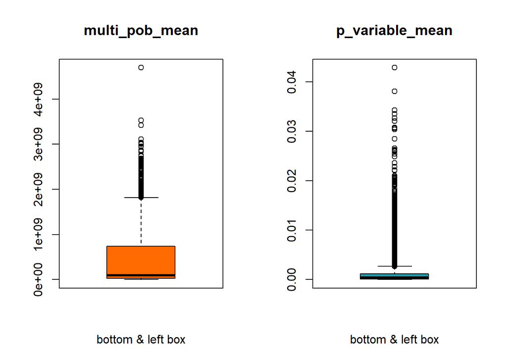

```r
par(mfrow = c(1,2))
boxplot(tabla_001$multi_pob_mean,  col="#FF6B00" , xlab="bottom & left box",
        main = "multi_pob_mean",
        boxwex = 0.9)
boxplot(tabla_001$p_variable_mean , col="#2398AB" , xlab="bottom & left box",
        main = "p_variable_mean",
        boxwex = 0.9)
```

La línea central es la mediana y los extremos de la caja el primer y el tercer cuartil (rango intercuartílico), en el que cae el 50% de las observaciones.

### 1.3 Transformaciones sobre outliers

Podemos enmascarar outliers con transformaciones. Por ejemplo, podemos reemplazar los valores que estén debajo del quinto percentil y los que estén por sobre el 95 avo percentil con los valores medios, tal como lo hicimos previamente sobre los NAs o con las medianas.

#### 1.3.1 Reemplazo de outliers con promedios:

sobre **multi_pob_mean**:

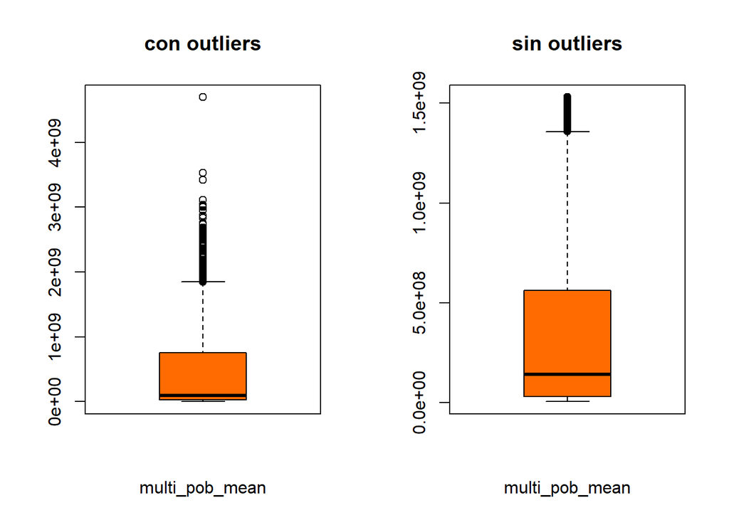

```r
outliers <- function(x, removeNA = TRUE){
      quantiles <- quantile(x, c(0.05, 0.95), na.rm = removeNA)
      x[x < quantiles[1]] <- mean(x, na.rm = removeNA)
      x[x > quantiles[2]] <- mean(x, na.rm = removeNA)
      x
}

outliers_data <- outliers(tabla_001$multi_pob_mean)

par(mfrow = c(1,2))
boxplot(tabla_001$multi_pob,   col="#FF6B00" , xlab="multi_pob_mean", main = "con outliers")
boxplot(outliers_data,  col="#FF6B00" , xlab="multi_pob_mean", main = "sin outliers")
```

#### 1.3.2 Reemplazo de outliers con medianas:

sobre **multi_pob_mean**:

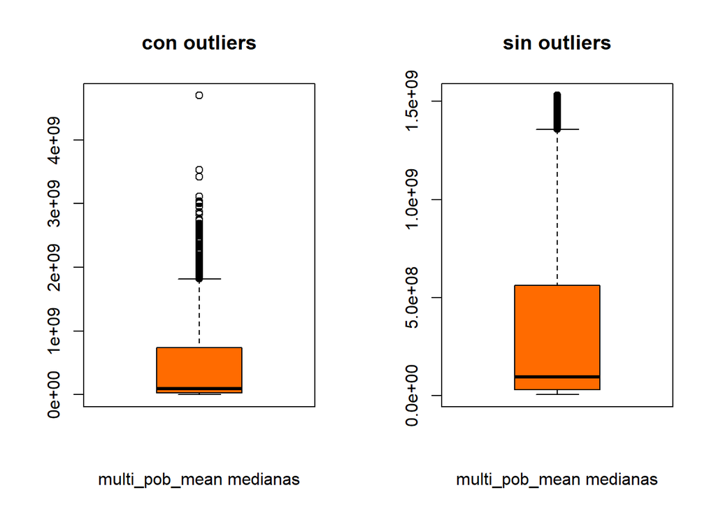

```r
outliers <- function(x, removeNA = TRUE){
      quantiles <- quantile(x, c(0.05, 0.95), na.rm = removeNA)
      x[x < quantiles[1]] <- median(x, na.rm = removeNA)
      x[x > quantiles[2]] <- median(x, na.rm = removeNA)
      x
}

outliers_data <- outliers(tabla_001$multi_pob_mean)

par(mfrow = c(1,2))
boxplot(tabla_001$multi_pob_mean,   col="#FF6B00" , xlab="multi_pob_mean medianas", main = "con outliers")
boxplot(outliers_data,  col="#FF6B00" , xlab="multi_pob_mean medianas", main = "sin outliers")
```

#### 1.3.3 Sustitución de outliers

Sustituímos los valores que están fuera de los bigotes con los valores del percentil 5 y el 95 respectivamente.

sobre **multi_pob_mean**:

```r
replace_outliers <- function(x, removeNA = TRUE){
     qrts <- quantile(x, probs = c(0.25, 0.75), na.rm =removeNA)
      caps <- quantile(x, probs = c(0.05, 0.95), na.rm =removeNA)
      iqr <- qrts[2] - qrts[1]
      h <- 1.5*iqr
      x[x < qrts[1] - h] <- caps[1]
      x[x > qrts[2] + h] <- caps[2]
      x
}
```

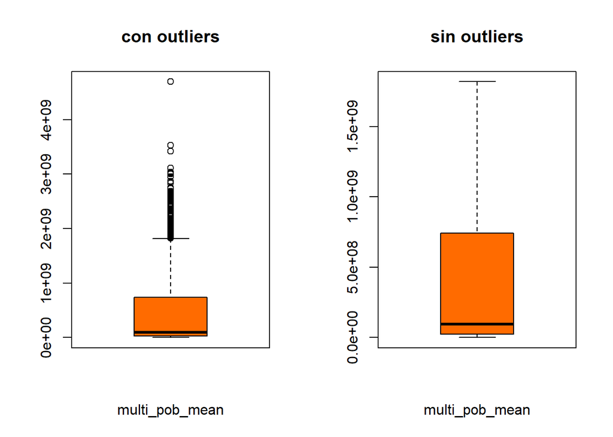

```r
multi_pob_capped <- replace_outliers(tabla_001$multi_pob_mean)
par(mfrow = c(1,2))
boxplot(tabla_001$multi_pob_mean,    col="#FF6B00" , xlab="multi_pob_mean", main = "con outliers")
boxplot(multi_pob_capped, col="#FF6B00" , xlab="multi_pob_mean", main = "sin outliers")
```

```r
length(multi_pob_capped)
```

```
## [1] 12671
```

Vemos que resulta mucho mejor ésta última técnica, por lo que lo aplicamos para los campos multi_pob_mean y p_variable_mean.

```r
p_variable_capped_multi_pob_mean <- replace_outliers(tabla_001$multi_pob_mean)
p_variable_capped_p_variable_mean <- replace_outliers(tabla_001$p_variable_mean)
```

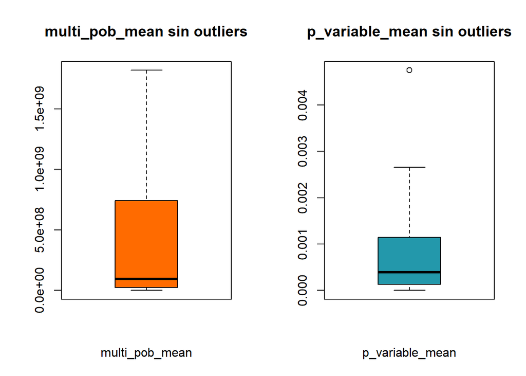

```r
par(mfrow = c(1,2))

boxplot(p_variable_capped_multi_pob_mean, col="#FF6B00" , xlab="multi_pob_mean", main = "multi_pob_mean sin outliers")

boxplot(p_variable_capped_p_variable_mean, col="#2398AB" , xlab="p_variable_mean", main = "p_variable_mean sin outliers")
```

## 2 Histogramas y densidades

Histograma y densidad para multi_pob_mean sin outliers

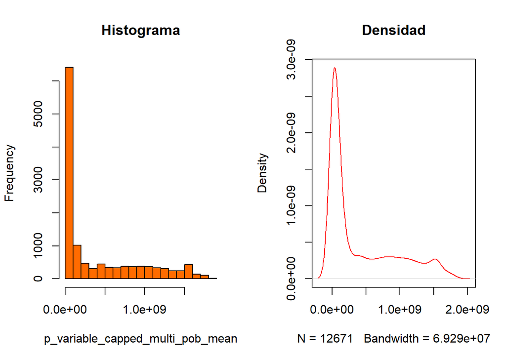

```r
par(mfrow = c(1,2))
hist(p_variable_capped_multi_pob_mean, col="#FF6B00", main="Histograma")
plot(density(p_variable_capped_multi_pob_mean), main="Densidad", col="red")
```

Histograma y densidad para p_variable_mean sin outliers

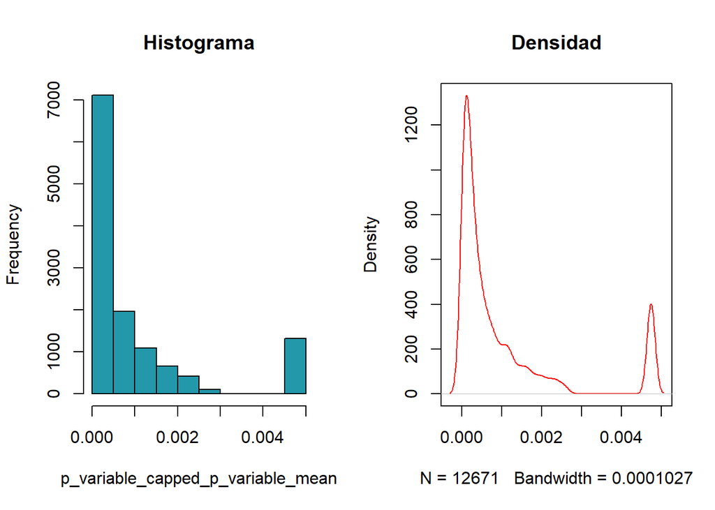

```r
par(mfrow = c(1,2))
hist(p_variable_capped_p_variable_mean, col="#2398AB" ,main="Histograma")
plot(density(p_variable_capped_p_variable_mean), main="Densidad", col="red")
```

## 3 Aplicación al dataframe

```r
x <- quantile(tabla_001$multi_pob_mean,c(0.05,0.95))
data_clean <- tabla_001[tabla_001$multi_pob_mean >= x[1] & tabla_001$multi_pob_mean <= x[2],]
```

```r
y <- quantile(data_clean$p_variable_mean,c(0.05,0.95))
data_clean <- data_clean[data_clean$p_variable_mean >= y[1] & data_clean$p_variable_mean <= y[2],]
```

```r
head(data_clean,10)
```

```
##           zona código.x Freq.x anio           p     comuna.x promedio_i  año
## 1  10101011001    10101     60 2017 0.005536588 Puerto Montt   268732.4 2017
## 2  10101011002    10101    177 2017 0.016332933 Puerto Montt   268732.4 2017
## 3  10101021001    10101     82 2017 0.007566670 Puerto Montt   268732.4 2017
## 4  10101021002    10101     77 2017 0.007105287 Puerto Montt   268732.4 2017
## 5  10101021003    10101     70 2017 0.006459352 Puerto Montt   268732.4 2017
## 6  10101021004    10101     99 2017 0.009135370 Puerto Montt   268732.4 2017
## 7  10101021005    10101    171 2017 0.015779275 Puerto Montt   268732.4 2017
## 8  10101031001    10101    133 2017 0.012272769 Puerto Montt   268732.4 2017
## 9  10101031002    10101    115 2017 0.010611793 Puerto Montt   268732.4 2017
## 10 10101031003    10101     94 2017 0.008673987 Puerto Montt   268732.4 2017
##    comuna.y personas Ingresos_expandidos Freq.y p_poblacional código.y
## 1     10101   245902         66081845388    584   0.002374930    10101
## 2     10101   245902         66081845388   2941   0.011960049    10101
## 3     10101   245902         66081845388   3953   0.016075510    10101
```

[output cut: 18 more lines]

## 4 Modelo lineal

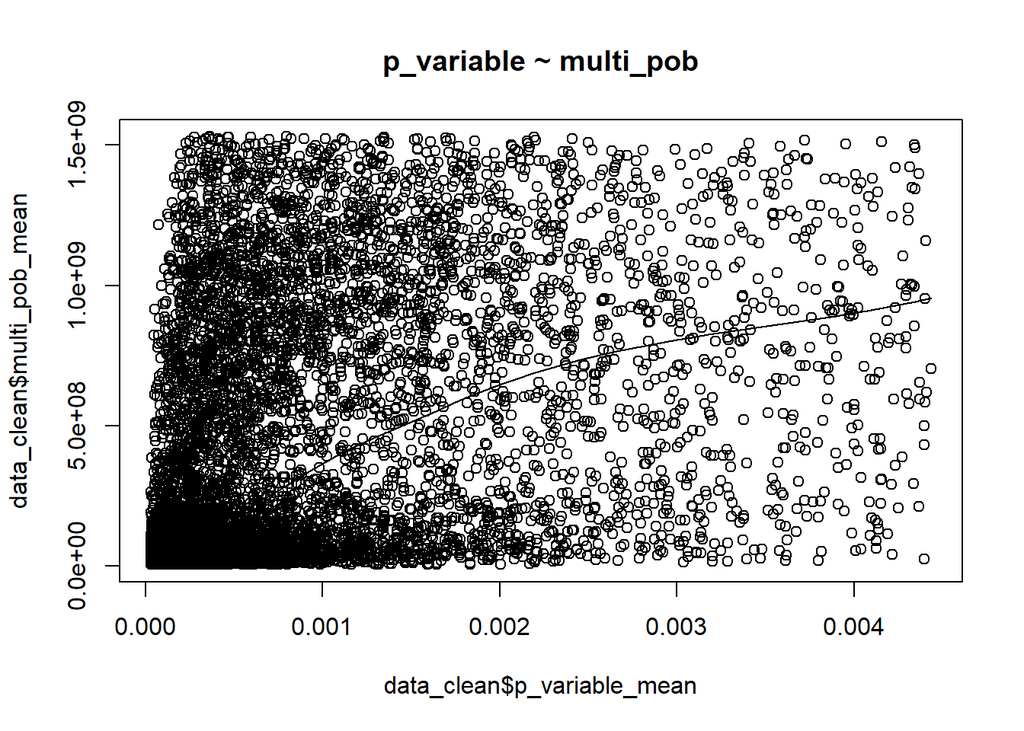

```r
scatter.smooth(x=data_clean$p_variable_mean, y=data_clean$multi_pob_mean, main="p_variable ~ multi_pob")
```

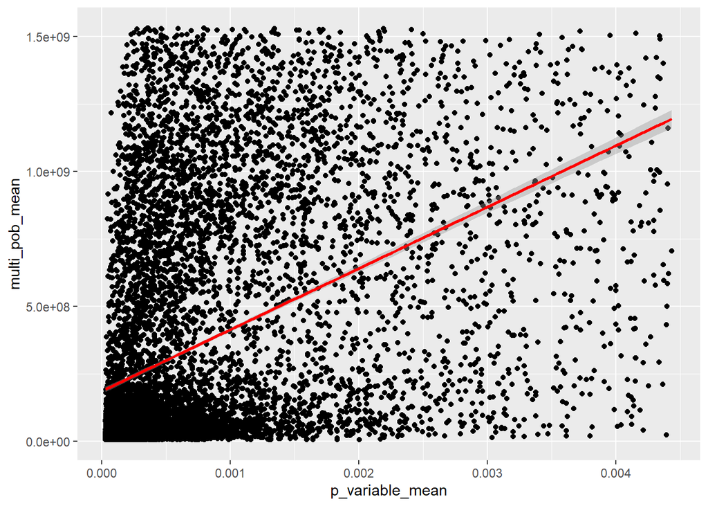

```r
ggplot(data_clean, aes(x = p_variable_mean, y = multi_pob_mean)) +
  geom_point() +
  stat_smooth(method = "lm", col = "red")
```

```r
linearMod <- lm( multi_pob_mean~p_variable_mean , data=data_clean)
summary(linearMod)
```

```
##
## Call:
## lm(formula = multi_pob_mean ~ p_variable_mean, data = data_clean)
##
## Residuals:
##        Min         1Q     Median         3Q        Max
## -1.161e+09 -2.168e+08 -1.712e+08  1.945e+08  1.279e+09
##
## Coefficients:
##                  Estimate Std. Error t value Pr(>|t|)
## (Intercept)     1.862e+08  5.119e+06   36.38   <2e-16 ***
## p_variable_mean 2.271e+11  4.537e+09   50.05   <2e-16 ***
## ---
## Signif. codes:  0 '***' 0.001 '**' 0.01 '*' 0.05 '.' 0.1 ' ' 1
##
## Residual standard error: 394700000 on 10271 degrees of freedom
## Multiple R-squared:  0.1961, Adjusted R-squared:  0.196
## F-statistic:  2505 on 1 and 10271 DF,  p-value: < 2.2e-16
```

### 4.1 Análisis del $R^2$ (coeficiente de determinación)

El $R^2$ es una medida estadística de qué tan cerca están los datos de la línea de regresión ajustada.

Es el porcentaje de la variación en la variable de respuesta que es explicado por un modelo lineal. Es decir:

$$R^2 = \frac{Variación\ explicada}{variación\ total}$$

Cuanto mayor sea la varianza explicada por el modelo de regresión, más cerca estarán los puntos de los datos de la línea de regresión ajustada.

Un valor bajo de $R^2$ no es inherentemente malo. Si el valor del $R^2$ es bajo pero se tienen predictores estadísticamente significativos, aún se puede obtener conclusiones importantes acerca de la asociación entre los cambios en los valores de los predictores y los cambios en el valor de respuesta. Independientemente del $R^2$, los coeficientes significativos aún representan el cambio medio en la respuesta para una unidad de cambio en el predictor mientras se mantienen constantes los otros predictores del modelo.

### 4.2 Análisis de los residuos

Los residuos son los errores que se cometen en la estimación.

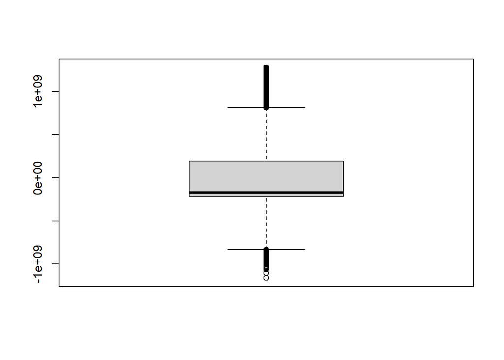

```r
boxplot(linearMod$residuals)
```

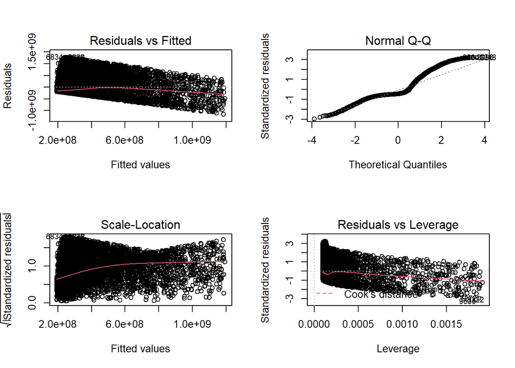

```r
par(mfrow = c (2,2))
plot(linearMod)
```

#### 4.2.1 Residuos versus valores ajustados

Corroboramos que los residuos sigan un patrón lineal. La línea es recta y horizontal, por lo que **deducimos que la relación es efectivamente lineal**. Se busca verificar la linealidad entre las variables de entrada y salida. Un modelo lineal nunca podrá capturar una relación no lineal.

## 5 Fórmulas alternativas del modelo lineal

```r
linearMod <- lm( multi_pob_mean~p_variable_mean^2 , data=data_clean)
summary(linearMod)
```

```
##
## Call:
## lm(formula = multi_pob_mean ~ p_variable_mean^2, data = data_clean)
##
## Residuals:
##        Min         1Q     Median         3Q        Max
## -1.161e+09 -2.168e+08 -1.712e+08  1.945e+08  1.279e+09
##
## Coefficients:
##                  Estimate Std. Error t value Pr(>|t|)
## (Intercept)     1.862e+08  5.119e+06   36.38   <2e-16 ***
## p_variable_mean 2.271e+11  4.537e+09   50.05   <2e-16 ***
## ---
## Signif. codes:  0 '***' 0.001 '**' 0.01 '*' 0.05 '.' 0.1 ' ' 1
##
## Residual standard error: 394700000 on 10271 degrees of freedom
## Multiple R-squared:  0.1961, Adjusted R-squared:  0.196
## F-statistic:  2505 on 1 and 10271 DF,  p-value: < 2.2e-16
```

### 5.2 Función logarítmica

$$\hat Y = \beta_0 + \beta_1 logX$$

```r
linearMod <- lm( multi_pob_mean~log(p_variable_mean) , data=data_clean)
summary(linearMod)
```

```
##
## Call:
## lm(formula = multi_pob_mean ~ log(p_variable_mean), data = data_clean)
##
## Residuals:
##        Min         1Q     Median         3Q        Max
## -787823248 -263759357  -83185338  176681879 1249525349
##
## Coefficients:
##                       Estimate Std. Error t value Pr(>|t|)
## (Intercept)          1.828e+09  2.452e+07   74.54   <2e-16 ***
## log(p_variable_mean) 1.873e+08  3.076e+06   60.87   <2e-16 ***
## ---
## Signif. codes:  0 '***' 0.001 '**' 0.01 '*' 0.05 '.' 0.1 ' ' 1
##
## Residual standard error: 377400000 on 10271 degrees of freedom
## Multiple R-squared:  0.2651, Adjusted R-squared:  0.265
## F-statistic:  3705 on 1 and 10271 DF,  p-value: < 2.2e-16
```

```r
linearMod <- lm( multi_pob_mean~p_variable_mean^3 , data=data_clean)
summary(linearMod)
```

```
##
## Call:
## lm(formula = multi_pob_mean ~ p_variable_mean^3, data = data_clean)
##
## Residuals:
##        Min         1Q     Median         3Q        Max
## -1.161e+09 -2.168e+08 -1.712e+08  1.945e+08  1.279e+09
##
## Coefficients:
##                  Estimate Std. Error t value Pr(>|t|)
## (Intercept)     1.862e+08  5.119e+06   36.38   <2e-16 ***
## p_variable_mean 2.271e+11  4.537e+09   50.05   <2e-16 ***
## ---
## Signif. codes:  0 '***' 0.001 '**' 0.01 '*' 0.05 '.' 0.1 ' ' 1
##
## Residual standard error: 394700000 on 10271 degrees of freedom
## Multiple R-squared:  0.1961, Adjusted R-squared:  0.196
## F-statistic:  2505 on 1 and 10271 DF,  p-value: < 2.2e-16
```

Vemos que el ajuste logarítmico nos ofrece el mayor $R^2$.

## 5 Referencias

https://rpubs.com/osoramirez/316691

https://dataintelligencechile.shinyapps.io/casenfinal

Manual_de_usuario_Censo_2017_16R.pdf

http://www.censo2017.cl/microdatos/

Censo de Población y Vivienda

https://www.ine.cl/estadisticas/sociales/censos-de-poblacion-y-vivienda/poblacion-y-vivienda

http://r-statistics.co/Linear-Regression.html

https://blog.minitab.com/es/analisis-de-regresion-como-puedo-interpretar-el-r-cuadrado-y-evaluar-la-bondad-de-ajuste